# Exploratory Data Analysis on Red Wine Quality Dataset

#### This dataset consists of 1599 observations of red wine information with 11 input variables based on physicochemical tests and the ouput variable based on sensory data.

#### The objective of this exploration is to identify which chemical properties influences the quality of red wines.

# Univariate Plots Section

#### I will first print summary of the dataset and then plot histograms and boxplots for each of the variables in the dataset which will be a valuable initial visualization.

```
##        X          fixed.acidity   volatile.acidity  citric.acid
##  Min.   :   1.0   Min.   : 4.60   Min.   :0.1200   Min.   :0.000
##  1st Qu.: 400.5   1st Qu.: 7.10   1st Qu.:0.3900   1st Qu.:0.090
##  Median : 800.0   Median : 7.90   Median :0.5200   Median :0.260
##  Mean   : 800.0   Mean   : 8.32   Mean   :0.5278   Mean   :0.271
##  3rd Qu.:1199.5   3rd Qu.: 9.20   3rd Qu.:0.6400   3rd Qu.:0.420
##  Max.   :1599.0   Max.   :15.90   Max.   :1.5800   Max.   :1.000
##  residual.sugar     chlorides       free.sulfur.dioxide
##  Min.   : 0.900   Min.   :0.01200   Min.   : 1.00
##  1st Qu.: 1.900   1st Qu.:0.07000   1st Qu.: 7.00
##  Median : 2.200   Median :0.07900   Median :14.00
##  Mean   : 2.539   Mean   :0.08747   Mean   :15.87
##  3rd Qu.: 2.600   3rd Qu.:0.09000   3rd Qu.:21.00
##  Max.   :15.500   Max.   :0.61100   Max.   :72.00
##  total.sulfur.dioxide    density             pH          sulphates
##  Min.   :  6.00       Min.   :0.9901   Min.   :2.740   Min.   :0.3300
##  1st Qu.: 22.00       1st Qu.:0.9956   1st Qu.:3.210   1st Qu.:0.5500
##  Median : 38.00       Median :0.9968   Median :3.310   Median :0.6200
##  Mean   : 46.47       Mean   :0.9967   Mean   :3.311   Mean   :0.6581
##  3rd Qu.: 62.00       3rd Qu.:0.9978   3rd Qu.:3.400   3rd Qu.:0.7300
##  Max.   :289.00       Max.   :1.0037   Max.   :4.010   Max.   :2.0000
##     alcohol         quality
##  Min.   : 8.40   Min.   :3.000
##  1st Qu.: 9.50   1st Qu.:5.000
##  Median :10.20   Median :6.000
##  Mean   :10.42   Mean   :5.636
##  3rd Qu.:11.10   3rd Qu.:6.000
##  Max.   :14.90   Max.   :8.000
```

```
## 'data.frame':    1599 obs. of  13 variables:
##  $ X                   : int  1 2 3 4 5 6 7 8 9 10 ...
##  $ fixed.acidity       : num  7.4 7.8 7.8 11.2 7.4 7.4 7.9 7.3 7.8 7.5 ...
##  $ volatile.acidity    : num  0.7 0.88 0.76 0.28 0.7 0.66 0.6 0.65 0.58 0.5 ...
##  $ citric.acid         : num  0 0 0.04 0.56 0 0 0.06 0 0.02 0.36 ...
##  $ residual.sugar      : num  1.9 2.6 2.3 1.9 1.9 1.8 1.6 1.2 2 6.1 ...
##  $ chlorides           : num  0.076 0.098 0.092 0.075 0.076 0.075 0.069 0.065 0.073 0.071 ...
##  $ free.sulfur.dioxide : num  11 25 15 17 11 13 15 15 9 17 ...
##  $ total.sulfur.dioxide: num  34 67 54 60 34 40 59 21 18 102 ...
##  $ density             : num  0.998 0.997 0.997 0.998 0.998 ...
##  $ pH                  : num  3.51 3.2 3.26 3.16 3.51 3.51 3.3 3.39 3.36 3.35 ...
##  $ sulphates           : num  0.56 0.68 0.65 0.58 0.56 0.56 0.46 0.47 0.57 0.8 ...
##  $ alcohol             : num  9.4 9.8 9.8 9.8 9.4 9.4 9.4 10 9.5 10.5 ...
##  $ quality             : int  5 5 5 6 5 5 5 7 7 5 ...
```

#### For each of the variables the distribution of the variable will be checked with and without outliers.

#### Fixed acidity:

```
## [1] "fixed.acidity"
##  fixed.acidity
##  Min.   : 4.60
##  1st Qu.: 7.10
##  Median : 7.90
##  Mean   : 8.32
##  3rd Qu.: 9.20
##  Max.   :15.90
```

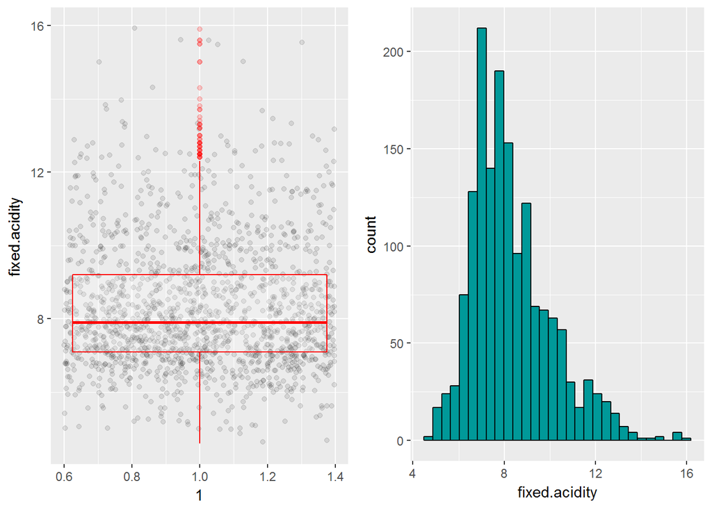

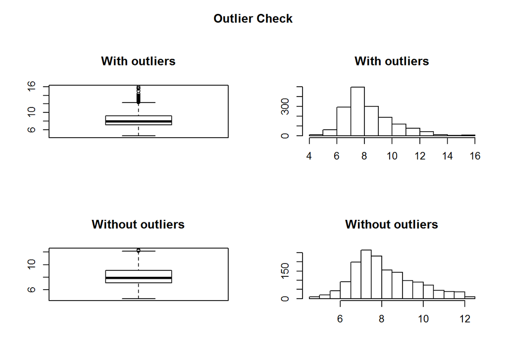

#### The fixed acidity variable is nonvolatile type. The range of this variable is between 4.60 and 15.90, with a mean of 8.32. The plot is positively skewed and has outliers as evident from the boxplot.

#### Volatile acidity:

```
## [1] "volatile.acidity"
##  volatile.acidity
##  Min.   :0.1200
##  1st Qu.:0.3900
##  Median :0.5200
##  Mean   :0.5278
##  3rd Qu.:0.6400
##  Max.   :1.5800
```

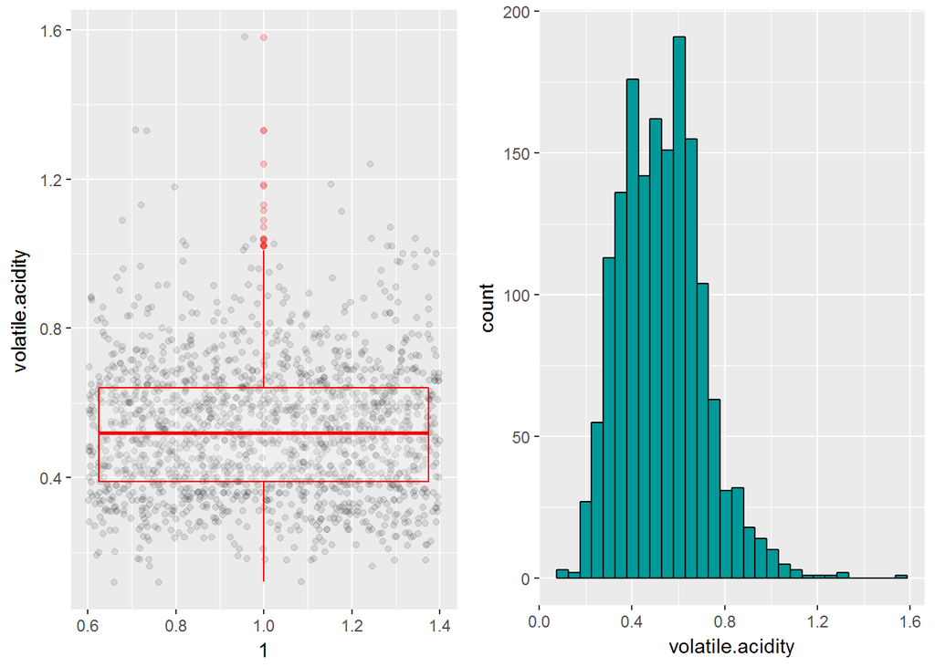

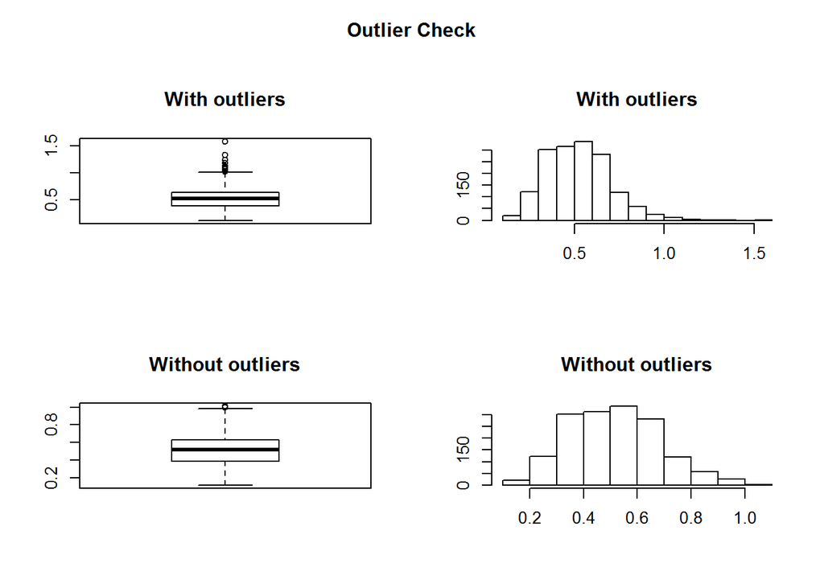

#### The volatile acidity variable is the amount of acetic acid in wine, which at too high of levels can lead to an unpleasant, vinegar taste. This variable has a range between 0.12 and 1.58 with a mean of 0.5278. The plot is positively skewed and has outliers.

#### Citric acid:

```
## [1] "citric.acid"
##   citric.acid
##  Min.   :0.000
##  1st Qu.:0.090
##  Median :0.260
##  Mean   :0.271
##  3rd Qu.:0.420
##  Max.   :1.000
```

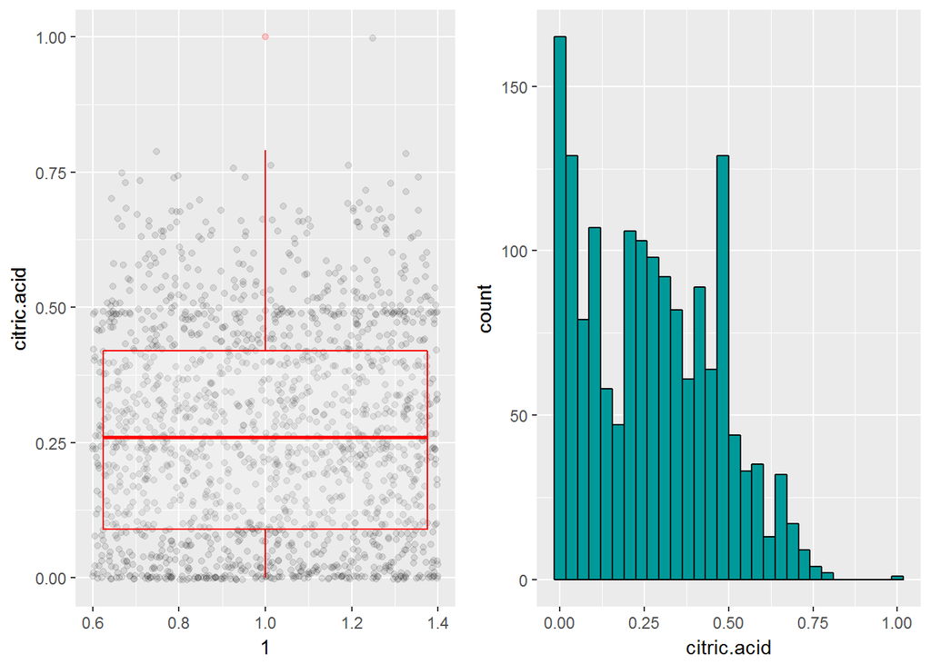

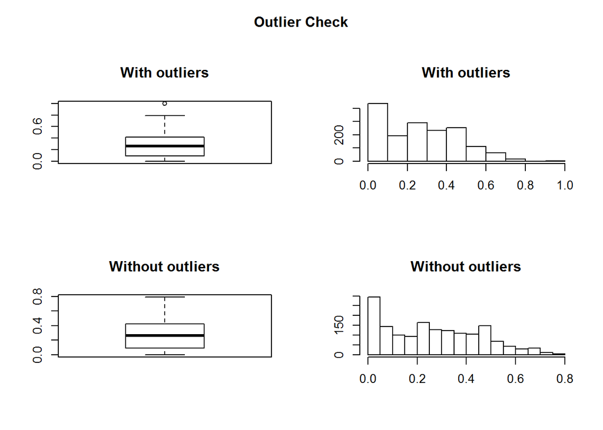

#### The citric acid variable is found in small quantities and can add ‘freshness’ and flavor to wines. This plot is positively skewed and has a range between 0.000 and 1.000 with a mean of 0.271. This variable has outliers.

#### Residual sugar:

```
## [1] "residual.sugar"
##  residual.sugar
##  Min.   : 0.900
##  1st Qu.: 1.900
##  Median : 2.200
##  Mean   : 2.539
##  3rd Qu.: 2.600
##  Max.   :15.500
```

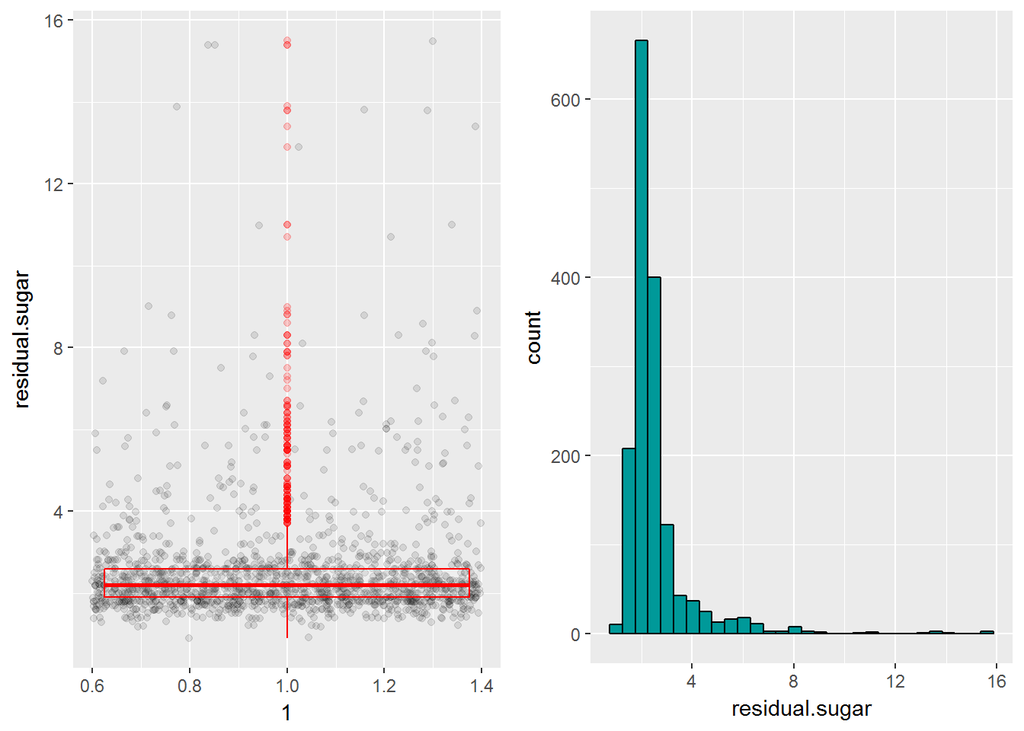

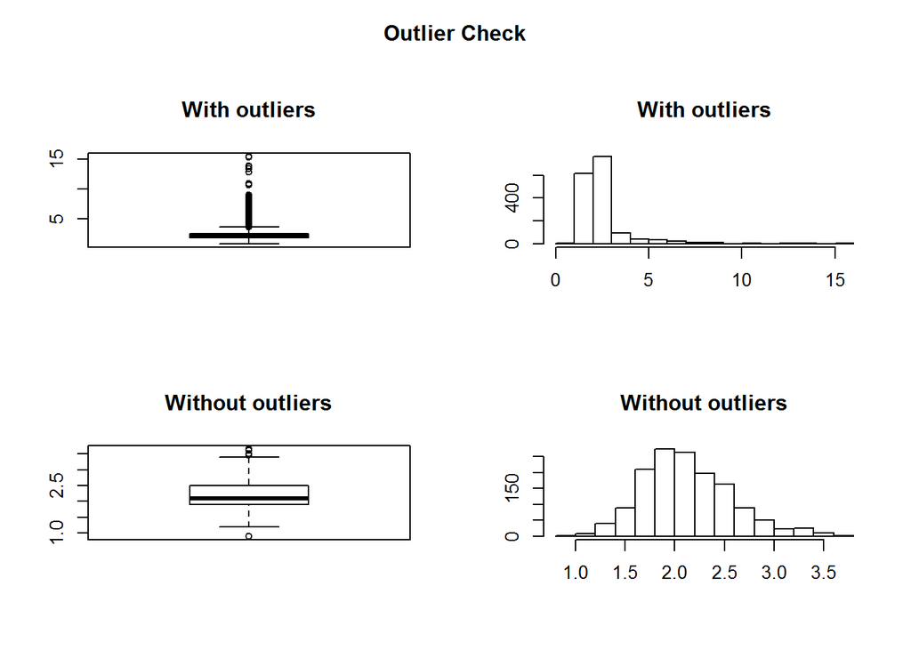

#### The residual sugar variable is the amount of sugar remaining after fermentation stops. The range of values is between 0.900 and 15.500 with a mean of 2.539. The plot is positively skewed and has outliers.

#### Chlorides:

```
## [1] "chlorides"
##    chlorides
##  Min.   :0.01200
##  1st Qu.:0.07000
##  Median :0.07900
##  Mean   :0.08747
##  3rd Qu.:0.09000
##  Max.   :0.61100
```

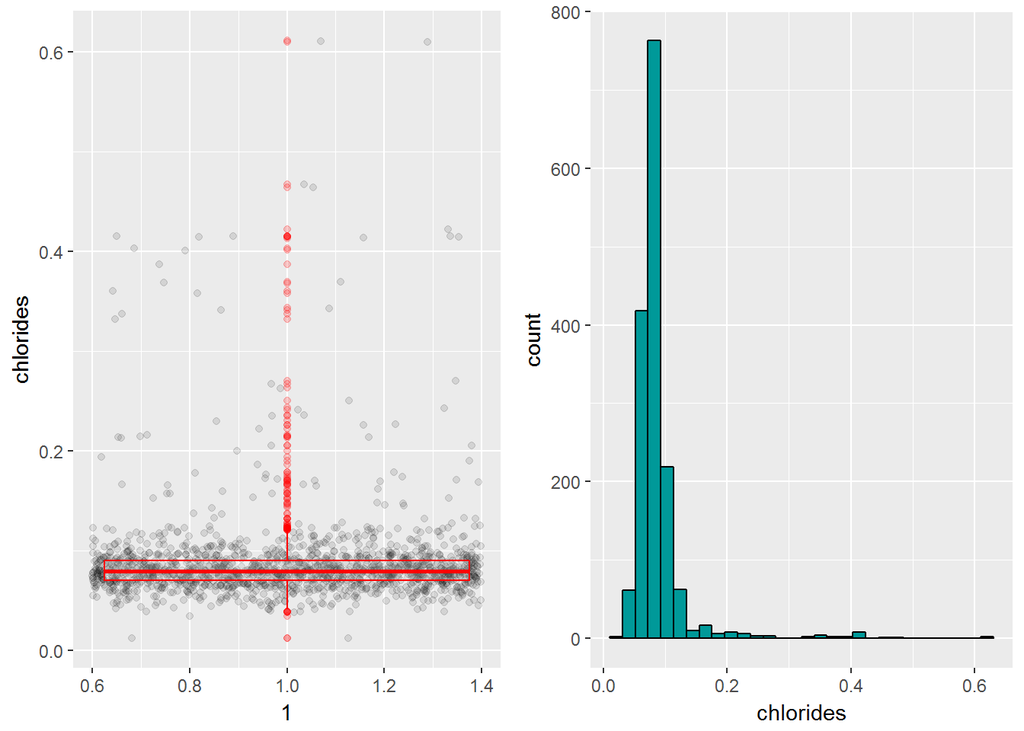

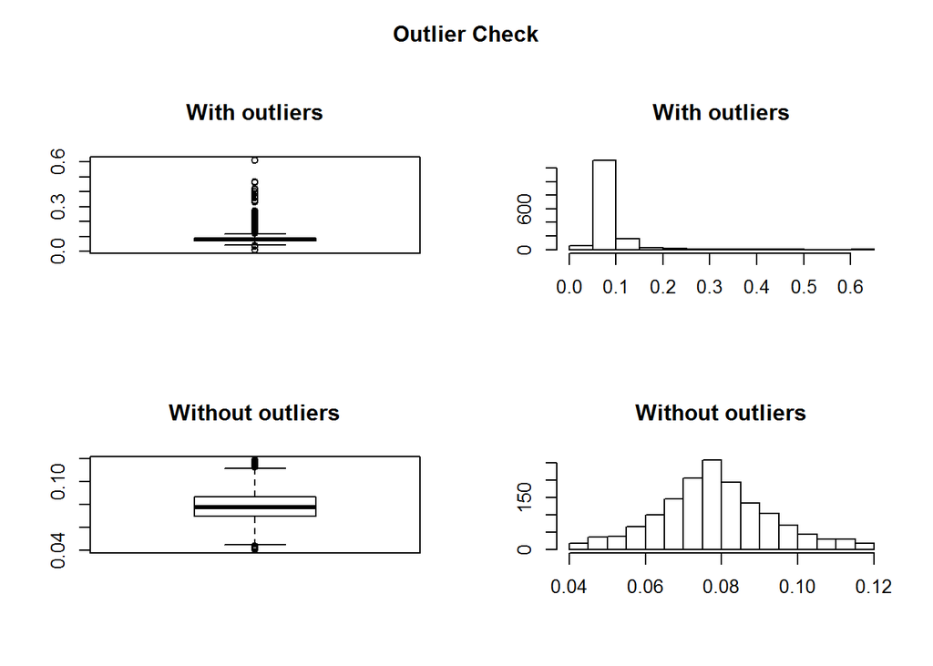

#### The chloride variable is the amount of salt in the wine. The range of values is between 0.01200 and 0.61100 with a mean of 0.08747. The plot is positively skewed and has some outliers.

#### Free sulfur dioxide:

```
## [1] "free.sulfur.dioxide"
##  free.sulfur.dioxide
##  Min.   : 1.00
##  1st Qu.: 7.00
##  Median :14.00
##  Mean   :15.87
##  3rd Qu.:21.00
##  Max.   :72.00
```

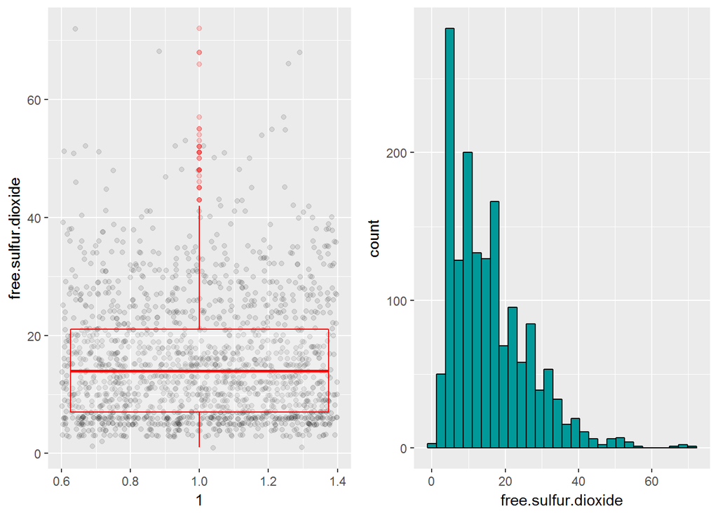

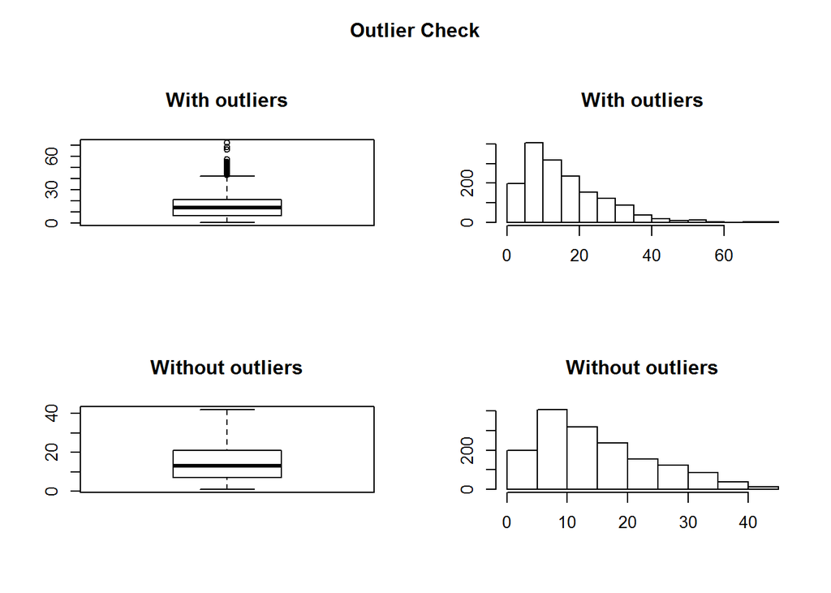

#### The free sulfur dioxide variable prevents microbial growth and the oxidation of wine. The range of values is between 1.00 and 72.00 with a mean of 15.87. The plot is positively skewed and has some outliers.

#### Total sulfur dioxide:

```
## [1] "total.sulfur.dioxide"
##  total.sulfur.dioxide
##  Min.   :  6.00
##  1st Qu.: 22.00
##  Median : 38.00
##  Mean   : 46.47
##  3rd Qu.: 62.00
##  Max.   :289.00
```

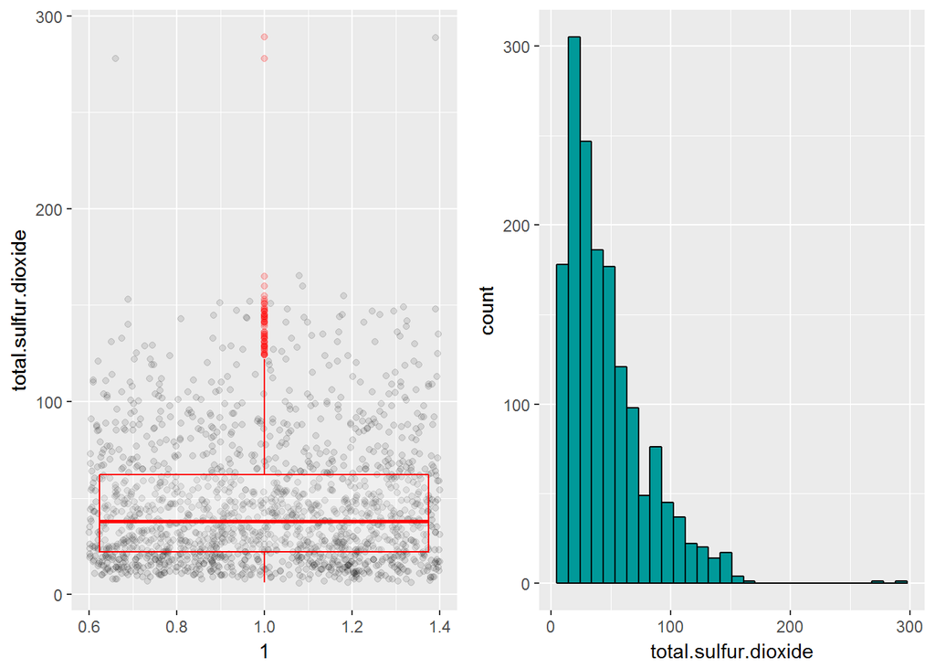

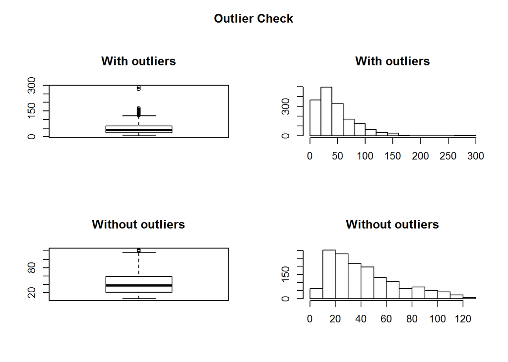

#### The total sulfur dioxide variable is undetected in small concentrations and is very evident in smell and taste in high concentrations. The range of this variable is between 6.00 and 289.00 with a mean of 46.47. The plot is positively skewed and has outliers.

#### Density:

```
## [1] "density"
##     density
##  Min.   :0.9901
##  1st Qu.:0.9956
##  Median :0.9968
##  Mean   :0.9967
##  3rd Qu.:0.9978
##  Max.   :1.0037
```

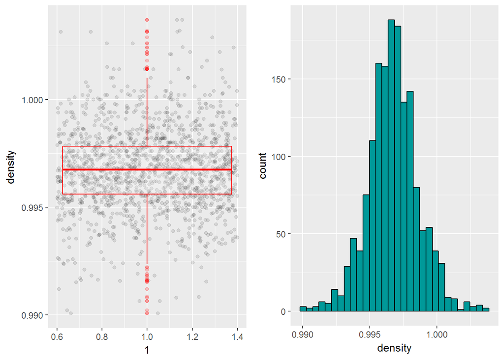

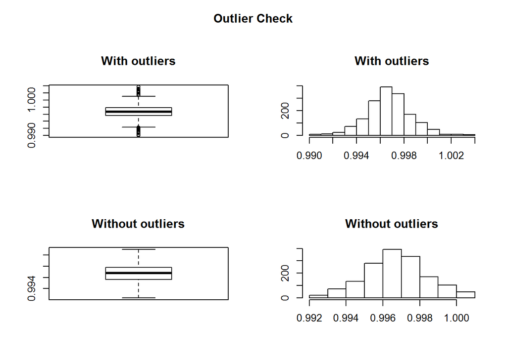

#### The density plot is normal shaped with a range between 0.9901 and 1.0037 and mean of 0.9967. It has some outliers.

#### pH:

```
## [1] "pH"
##        pH
##  Min.   :2.740
##  1st Qu.:3.210
##  Median :3.310
##  Mean   :3.311
##  3rd Qu.:3.400
##  Max.   :4.010
```

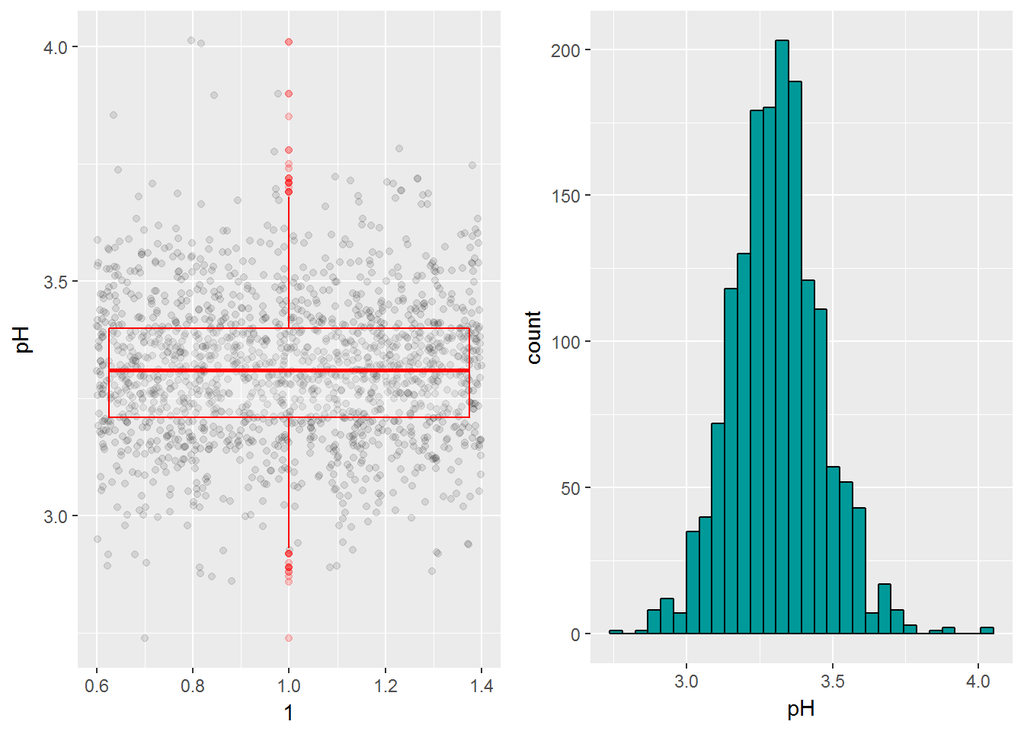

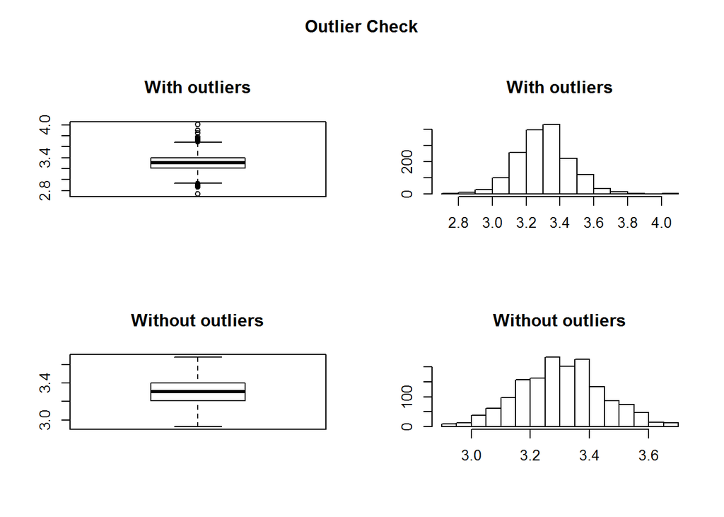

#### The pH variable describes how acidic or basic a wine is on a scale from 0 (very acidic) to 14. The plot is normal shaped and has a range between 2.740 and 4.010 with a mean value of 3.311. There are some outliers.

#### Sulphates:

```
## [1] "sulphates"
##    sulphates
##  Min.   :0.3300
##  1st Qu.:0.5500
##  Median :0.6200
##  Mean   :0.6581
##  3rd Qu.:0.7300
##  Max.   :2.0000
```

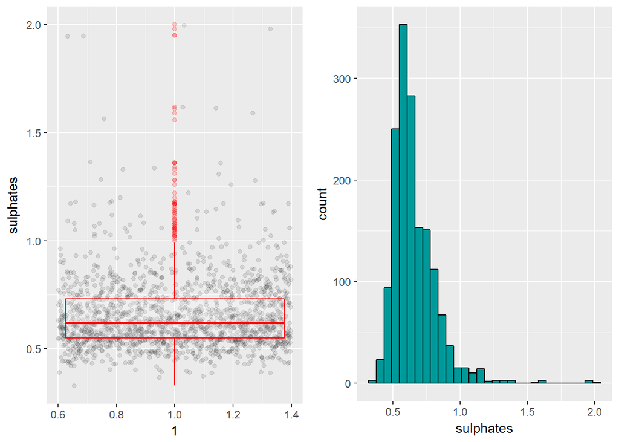

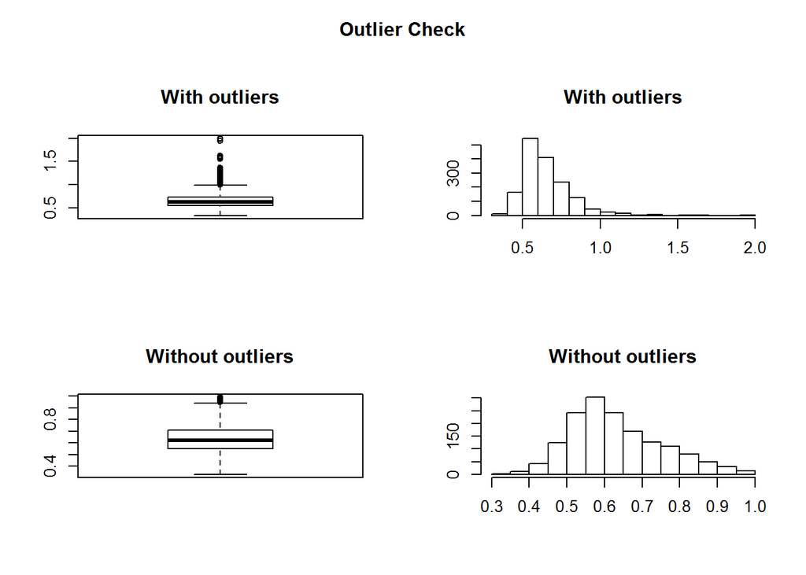

#### The sulphates variable is a wine additive that acts as an antimicrobial and antioxidant. It has a range between 0.3300 and 2.000 with a mean of 0.6581,is positively skewed and has outliers.

#### Alcohol:

```
## [1] "alcohol"
##     alcohol
##  Min.   : 8.40
##  1st Qu.: 9.50
##  Median :10.20
##  Mean   :10.42
##  3rd Qu.:11.10
##  Max.   :14.90
```

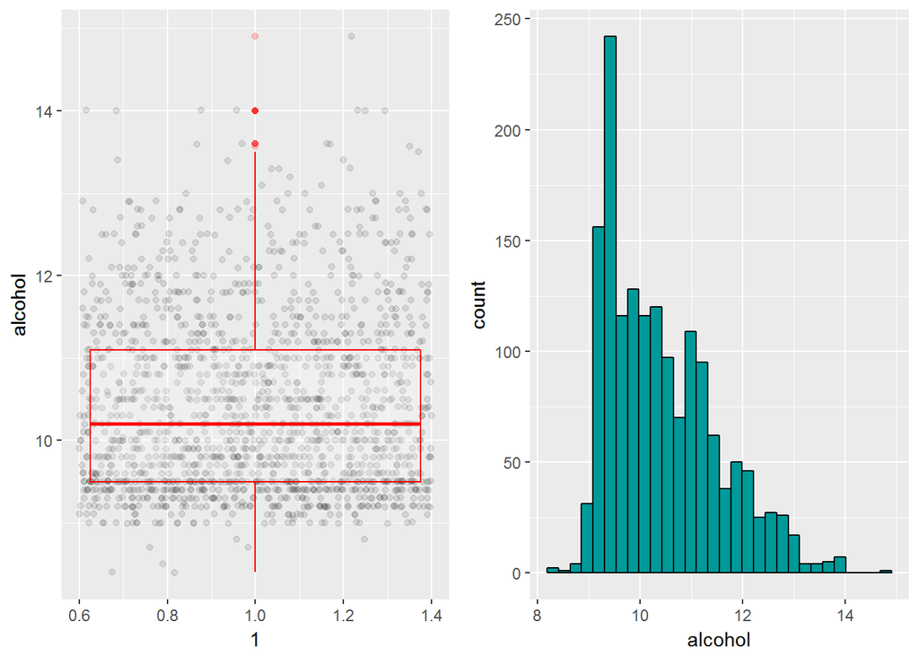

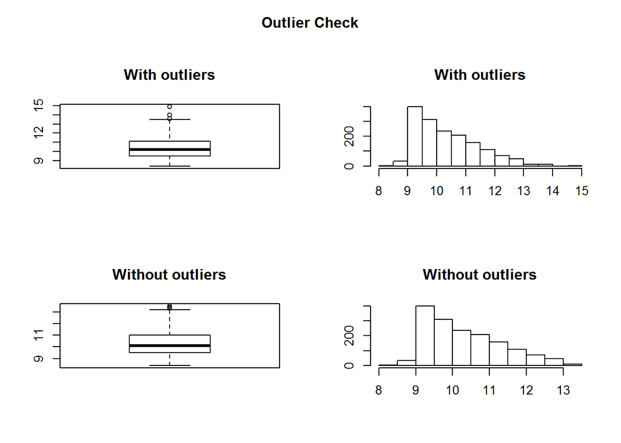

#### The alcohol variable is the percent alcohol content of the wine. It has a range between 8.40 and 14.90, has a mean of 10.42,is positively skewed and has a few outliers.

#### Quality:

```
## [1] "quality"
##     quality
##  Min.   :3.000
##  1st Qu.:5.000
##  Median :6.000
##  Mean   :5.636
##  3rd Qu.:6.000
##  Max.   :8.000
```

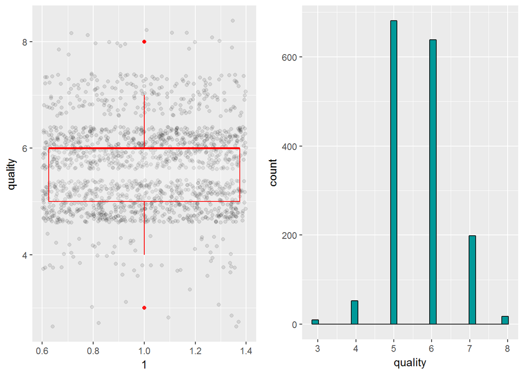

#### * From the summary, I found that there were a total of 1599 wines, out of which 1319 wines have a quality score of 5 and 6 with 18 wines having a high score of 8 and 10 wines with low score of 3

#### * Only two variables density and ph are roughly normally distributed.

#### * Variables fixed acidity, volatile acidity, citric acid, free sulfur dioxide, total sulfur dioxide, alchohol, sulphates, chlorides and residual sugar are all positively skewed.

#### * Almost all of the variables have outliers. After analyzing the plot distribution before and after the outliers are removed, I decided to remove the outliers and replace with ‘NA’ for the following variables - citric acid,residual sugar and free sulfur dioxide.

# Univariate Analysis

### What is the structure of your dataset?

```
## 'data.frame':    1427 obs. of  12 variables:
##  $ fixed.acidity       : num  7.4 7.8 7.8 11.2 7.4 7.4 7.9 7.3 7.8 6.7 ...
##  $ volatile.acidity    : num  0.7 0.88 0.76 0.28 0.7 0.66 0.6 0.65 0.58 0.58 ...
##  $ citric.acid         : num  0 0 0.04 0.56 0 0 0.06 0 0.02 0.08 ...
##  $ residual.sugar      : num  1.9 2.6 2.3 1.9 1.9 1.8 1.6 1.2 2 1.8 ...
##  $ chlorides           : num  0.076 0.098 0.092 0.075 0.076 0.075 0.069 0.065 0.073 0.097 ...
##  $ free.sulfur.dioxide : num  11 25 15 17 11 13 15 15 9 15 ...
##  $ total.sulfur.dioxide: num  34 67 54 60 34 40 59 21 18 65 ...
##  $ density             : num  0.998 0.997 0.997 0.998 0.998 ...
##  $ pH                  : num  3.51 3.2 3.26 3.16 3.51 3.51 3.3 3.39 3.36 3.28 ...
##  $ sulphates           : num  0.56 0.68 0.65 0.58 0.56 0.56 0.46 0.47 0.57 0.54 ...
##  $ alcohol             : num  9.4 9.8 9.8 9.8 9.4 9.4 9.4 10 9.5 9.2 ...
##  $ quality             : int  5 5 5 6 5 5 5 7 7 5 ...
##  - attr(*, "na.action")=Class 'omit'  Named int [1:172] 10 12 15 16 19 34 36 40 41 56 ...
##   .. ..- attr(*, "names")= chr [1:172] "10" "12" "15" "16" ...
```

### What is/are the main feature(s) of interest in your dataset?

#### The variable quality is the dependent variable in the dataset and all the other variables are independent. I would like to find out which of the 11 independent variables contribute to a better quality of wine.

### What other features in the dataset do you think will help support your investigation into your feature(s) of interest?

#### I think the residual sugar variable which determines the sweetness of the wine, the fixed acidity, volatile acidity and citric acid variables which could affect the taste of the wine could be potential variables of interest. I will check to see if any of these variables as well as the other variables are correlated to the quality variable.

### Did you create any new variables from existing variables in the dataset?

#### I created a new variable called rating that shows the rating of the wine quality as poor(3), fair(4), average(5), good(6), better(7) or best(8).

### Of the features you investigated, were there any unusual distributions? Did you perform any operations on the data to tidy, adjust, or change the form of the data? If so, why did you do this?

#### I removed the X variable since it contains just the row count and added a new variable rating which gives a rating of the quality of the red wines. I did this so that it’s easier to see the results in a graph rather than just numbers as shown below.

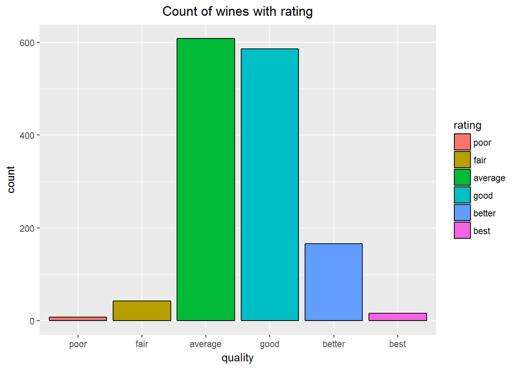

#### This plot clearly shows that most of the wines are of average and good quality.

# Bivariate Plots Section

#### I will first find if there is a correlation between any of the variables and the quality variable. This plot gives a good visual representation of correlation among the variables.

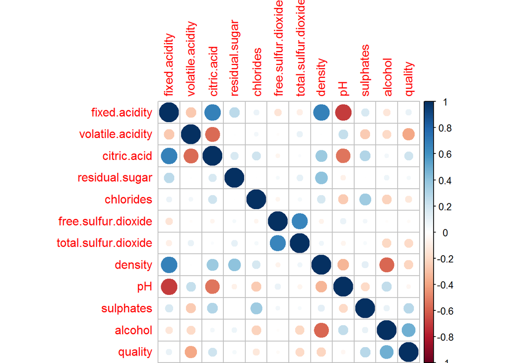

#### To get the actual correlation values,I used ggcorr function.

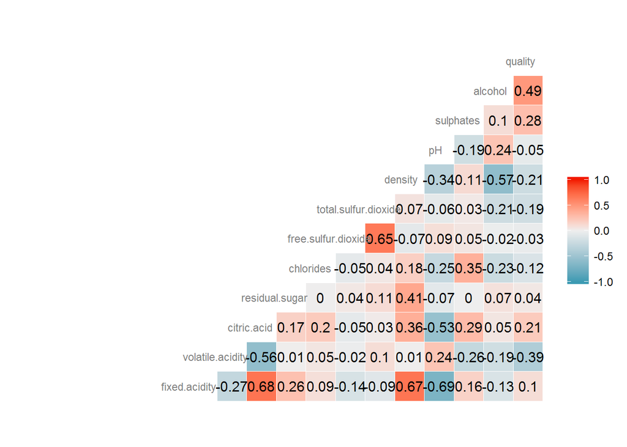

#### I checked the correlation between each of the independent variables and the dependent variable quality. The correlation between variable alcohol and quality is the highest (almost 0.5). There seems to be less correlation between the other variables and quality.

#### I then created boxplots for each of the variables to better understand the correlation with quality. I grouped the quality value and found the mean and median for each group. From the plot and the summary, I will know the correlation better. Since only five of the independent variables, alcohol,sulphates,density,citric acide and volatile acidity showed higher correlation with quality variable, I dropped the other variables from consideration.

### Volatile acidity:

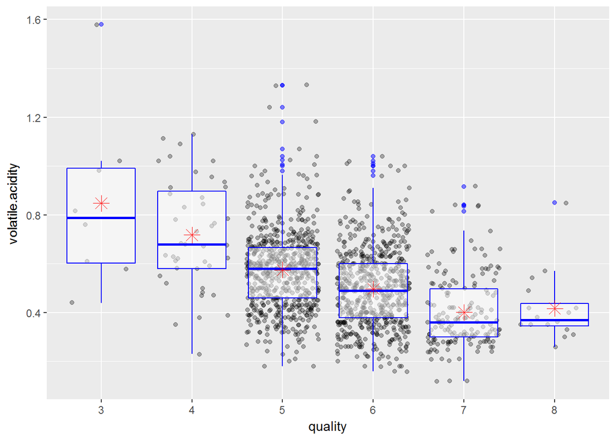

```
## # A tibble: 6 × 4
##   `factor(quality)` mean_value median_value     n
##              <fctr>      <dbl>        <dbl> <int>
## 1                 3  0.8481250       0.7875     8
## 2                 4  0.7181395       0.6800    43
## 3                 5  0.5745970       0.5800   608
## 4                 6  0.4971160       0.4900   586
## 5                 7  0.4011446       0.3600   166
## 6                 8  0.4175000       0.3700    16
```

#### Citric acid:

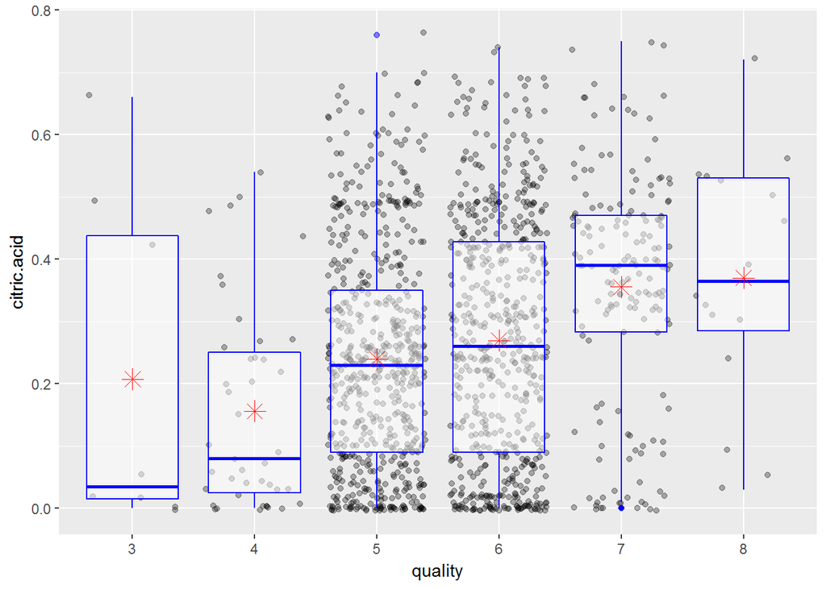

```
## # A tibble: 6 × 4
##   `factor(quality)` mean_value median_value     n
##              <fctr>      <dbl>        <dbl> <int>
## 1                 3  0.2075000        0.035     8
## 2                 4  0.1560465        0.080    43
## 3                 5  0.2396053        0.230   608
## 4                 6  0.2694539        0.260   586
## 5                 7  0.3554217        0.390   166
## 6                 8  0.3700000        0.365    16
```

#### Density:

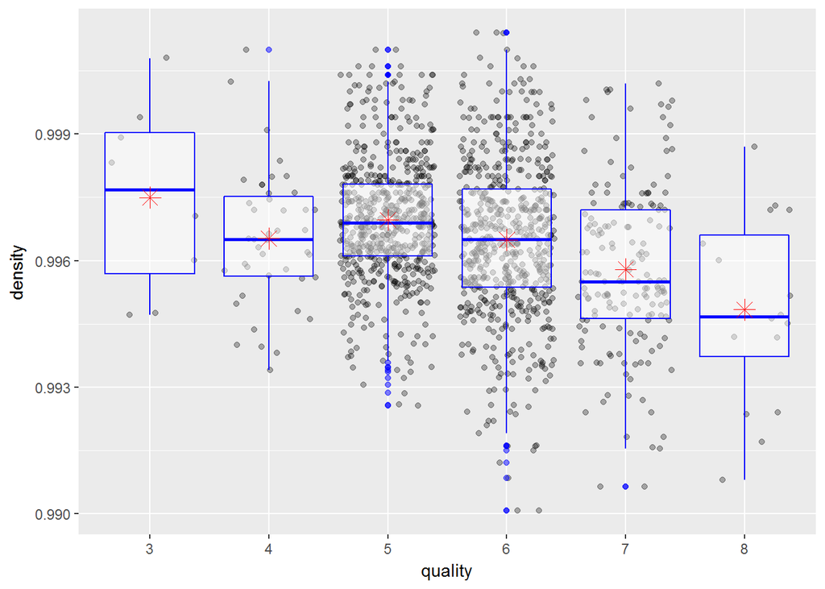

```
## # A tibble: 6 × 4
##   `factor(quality)` mean_value median_value     n
##              <fctr>      <dbl>        <dbl> <int>
## 1                 3  0.9974950     0.997685     8
## 2                 4  0.9965263     0.996500    43
## 3                 5  0.9969672     0.996900   608
## 4                 6  0.9964916     0.996495   586
## 5                 7  0.9957920     0.995500   166
## 6                 8  0.9948387     0.994670    16
```

#### Sulphates:

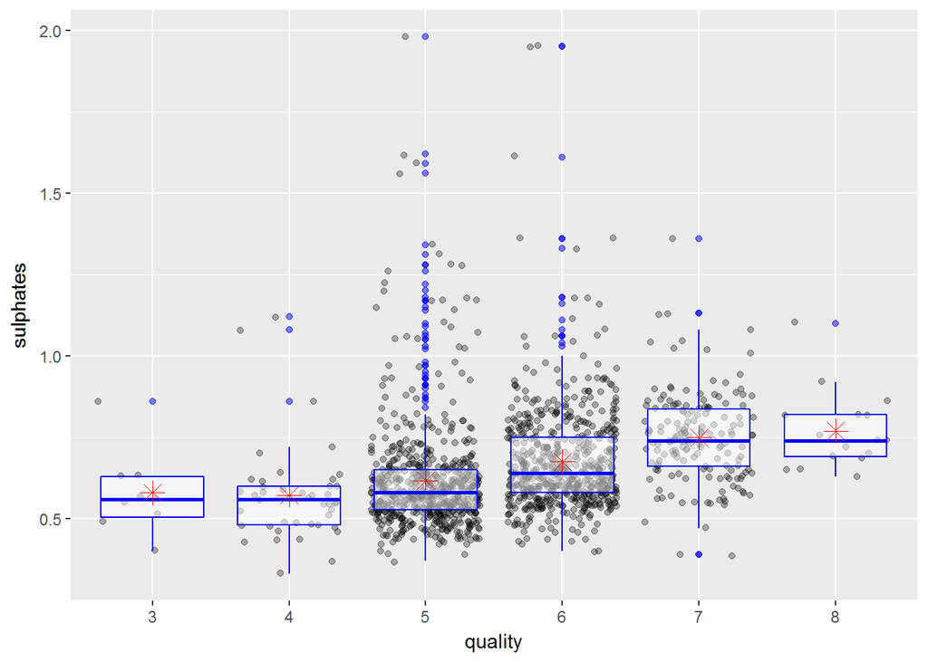

```
## # A tibble: 6 × 4
##   `factor(quality)` mean_value median_value     n
##              <fctr>      <dbl>        <dbl> <int>
## 1                 3  0.5800000         0.56     8
## 2                 4  0.5720930         0.56    43
## 3                 5  0.6168257         0.58   608
## 4                 6  0.6749659         0.64   586
## 5                 7  0.7487349         0.74   166
## 6                 8  0.7693750         0.74    16
```

#### Alcohol:

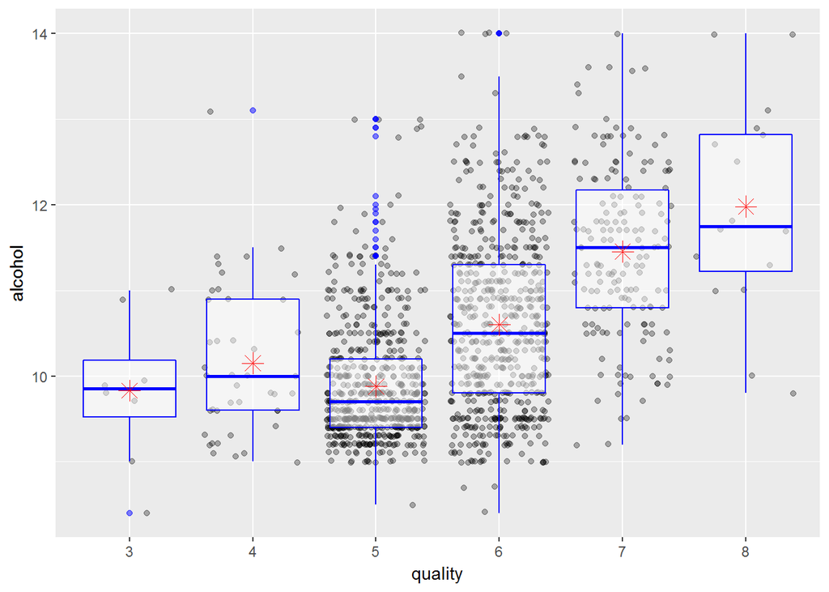

```
## # A tibble: 6 × 4
##   `factor(quality)` mean_value median_value     n
##              <fctr>      <dbl>        <dbl> <int>
## 1                 3   9.831250         9.85     8
## 2                 4  10.150000        10.00    43
## 3                 5   9.878783         9.70   608
## 4                 6  10.601849        10.50   586
## 5                 7  11.455522        11.50   166
## 6                 8  11.981250        11.75    16
```